# Challenge_3_dataset an_M9_00000060236_Nisaul Fadhilah

## TUGAS LAB IF540 MACHINE LEARNING

### WEEK 09 : Algoritma Partisi

#### Semester Genap 2022/2023

```python
# Run this code when you restart the machine
# Fill in with YOUR name and NIM
import datetime
import uuid

myName = "Nisa'ul Fadhilah"
myNIM = "0000060236"
```

```python
myDate = datetime.datetime.now()
myDevice = str(uuid.uuid1())

print("Name: \t\t{}".format(myName))
print("NIM: \t\t{}".format(myNIM))
print("Start: \t\t{}".format(myDate))
print("Device ID: \t{}".format(myDevice))
```

```
Name: 		Nisa'ul Fadhilah
NIM: 		0000060236
Start: 		2023-11-02 15:49:42.299188
Device ID: 	c3bd7e0a-795c-11ee-b25d-2c3b70a37f3c
```

### Dataset yang dipakai:

1. Fashion MNIST – sumber : https://www.kaggle.com/datasets/zalando-research/fashionmnist
2. Breast Cancer - sumber : https://scikit-learn.org/stable/modules/generated/sklearn.datasets.load_breast_cancer.html
3. Gender Classification – sumber : https://www.kaggle.com/datasets/hb20007/gender-classification

### Penjelasan Dataset

Fashion-MNIST adalah dataset gambar pakaian dengan 60,000 data latih dan 10,000 data uji. Setiap gambar berukuran 28x28 piksel dalam skala abu-abu dan diklasifikasikan ke dalam 10 kategori berbeda. Dataset ini digunakan untuk menguji performa algoritma machine learning dalam mengenali jenis pakaian berdasarkan gambar. Setiap gambar memiliki 784 nilai piksel yang menggambarkan tingkat kegelapan. Dataset ini merupakan pengganti dataset MNIST yang populer dalam pengujian algoritma machine learning.

Gender Classification berfokus pada konsep bahwa gender adalah konstruksi sosial, dan bagaimana perbedaan perlakuan antara laki-laki dan perempuan sejak lahir memengaruhi perilaku dan preferensi personal mereka sesuai dengan harapan sosial terkait gender. Dataset kecil ini mencoba untuk memprediksi gender seseorang berdasarkan preferensi personal mereka dengan akurasi di atas 50%. Data dikumpulkan dari mahasiswa universitas dari 21 negara yang belajar berbagai jurusan di berbagai negara. Data tersebut telah diproses dan dikelompokkan menjadi kategori yang dapat digunakan untuk analisis. Dengan perkembangan feminisme, perbedaan preferensi personal antara laki-laki dan perempuan semakin mengecil dalam beberapa tahun terakhir. Misalnya, warna-warna hangat seperti merah dan pink yang dulunya dianggap sebagai warna feminin, dan warna dingin seperti biru dianggap sebagai warna maskulin, saat ini dianggap ketinggalan zaman.

Dataset Breast Cancer adalah dataset kanker payudara Wisconsin yang digunakan untuk tugas klasifikasi biner. Terdapat dua kelas, yaitu "malignant" (ganas) dan "benign" (jinak). Terdapat total 569 sampel dengan 30 fitur numerik positif. Dataset ini dapat digunakan untuk mengembangkan model klasifikasi untuk membedakan antara kasus kanker payudara ganas dan jinak. Lebih lengkapnya, dataset ini memiliki 569 sampel dengan 212 sampel untuk kelas ganas (M) dan 357 sampel untuk kelas jinak (B). Terdapat 30 fitur yang merupakan atribut numerik yang dapat digunakan untuk melakukan prediksi klasifikasi.

### Hasil kerja

#### Importing system library

```python
import sys
```

#### Importing numpy library

```python
%matplotlib inline
import matplotlib.pyplot as plt
import seaborn as sns; sns.set()
import numpy as np
```

```python
pip install scikit-learn matplotlib
```

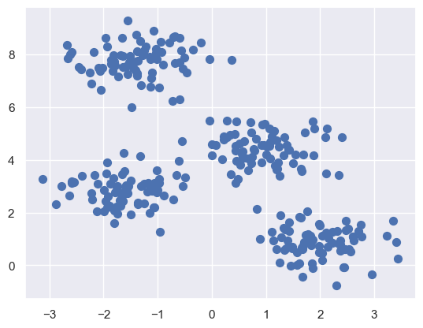

```python
from sklearn.datasets import make_blobs
X, y_true = make_blobs(n_samples=300, centers=4,
                      cluster_std=0.60, random_state=0)
plt.scatter(X[:, 0], X[:, 1], s=50);
```

```python
from sklearn.cluster import KMeans
kmeans = KMeans(n_clusters=4)
kmeans.fit(X)
y_kmeans = kmeans.predict(X)
```

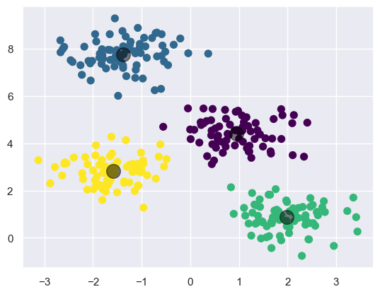

```python
plt.scatter(X[:, 0], X[:, 1], c=y_kmeans, s=50, cmap='viridis')

centers = kmeans.cluster_centers_
plt.scatter(centers[:, 0], centers[:, 1], c = 'black', s =200, alpha=0.5);
```

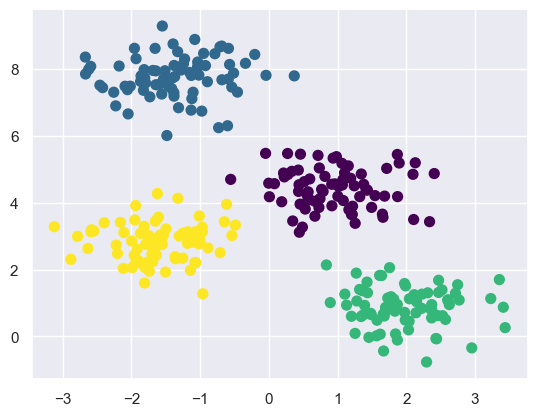

```python
from sklearn.metrics import pairwise_distances_argmin

def find_clusters(X, n_clusters, rseed=2):
    #1. randomly choose clusters
    rng = np.random.RandomState(rseed)
    i = rng.permutation(X.shape[0])[:n_clusters]
    centers = X[i]

    while True:
        #a. Assign labels based on closestr center
        labels = pairwise_distances_argmin(X, centers)

        #b. find new centers from means of points
        new_centers = np.array([X[labels == i].mean(0)
                               for i in range(n_clusters)])

        #c. Check for covergence
        if np.all(centers == new_centers):
            break
        centers = new_centers

    return centers, labels

centers, labels = find_clusters(X, 4)
plt.scatter(X[:, 0], X[:, 1], c=labels,
           s=50, cmap='viridis');
```

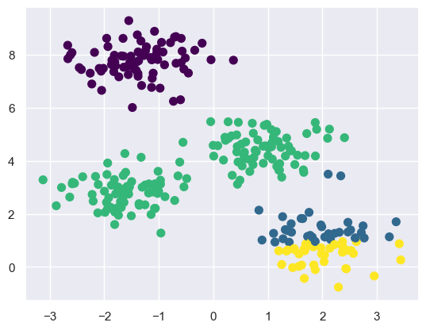

```python
centers, labels = find_clusters(X, 4, rseed=0)
plt.scatter(X[:, 0], X[:, 1], c=labels,
           s=50, cmap='viridis');
```

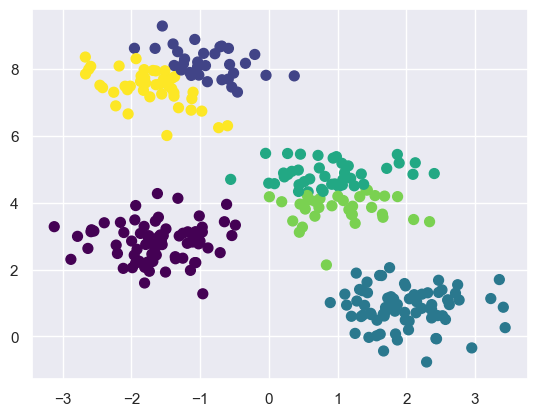

```python
labels = KMeans(6, random_state=0).fit_predict(X)
plt.scatter(X[:, 0], X[:, 1], c=labels,
           s=50, cmap='viridis');
```

```python
from sklearn.datasets import make_moons
X, y = make_moons(200, noise=.05, random_state=0)
```

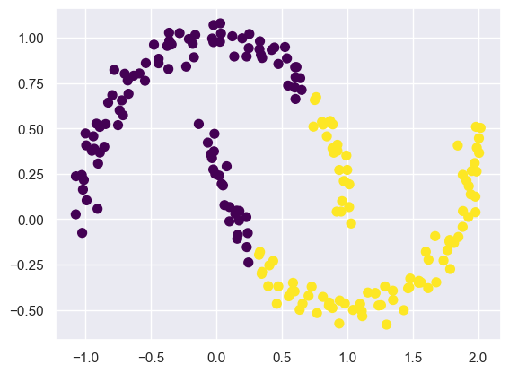

```python
labels = KMeans(2, random_state=0).fit_predict(X)
plt.scatter(X[:, 0], X[:, 1], c=labels,
           s=50, cmap='viridis');
```

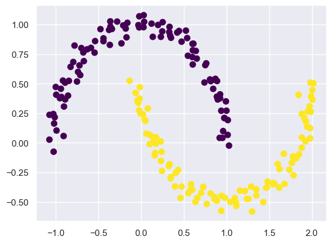

```python
from sklearn.cluster import SpectralClustering
model = SpectralClustering(n_clusters=2, affinity='nearest_neighbors',
                           assign_labels='kmeans')
labels = model.fit_predict(X)
plt.scatter(X[:, 0], X[:, 1], c=labels,
            s=50, cmap='viridis');
```

```python
import pandas as pd
fashion = pd.read_csv("fashion-mnist.csv")
print(fashion.shape)
```

```
(10000, 785)
```

```python
kmeans = KMeans(n_clusters=10, random_state=0)
clusters = kmeans.fit_predict(fashion.drop(columns=['label']))
kmeans.cluster_centers_.shape
```

```
(10, 784)
```

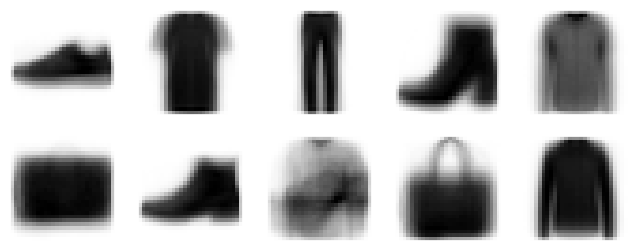

```python
fig, ax = plt.subplots(2, 5, figsize=(8, 3))
centers = kmeans.cluster_centers_.reshape(10, 28, 28)
for axi, center in zip(ax.flat, centers):
    axi.set(xticks=[], yticks=[])
    axi.imshow(center, interpolation='nearest', cmap=plt.cm.binary)
```

```python
from scipy.stats import mode
labels = np.zeros_like(clusters)
for i in range(10):
    mask = (clusters == i)
    labels[mask] = mode(fashion['label'][mask])[0]
```

```python
from sklearn.metrics import accuracy_score
accuracy_score(fashion['label'], labels)
```

```
0.5495
```

```python
target_names = [0, 1, 2, 3, 4, 5, 6, 7, 8, 9]
target_names
```

```
[0, 1, 2, 3, 4, 5, 6, 7, 8, 9]
```

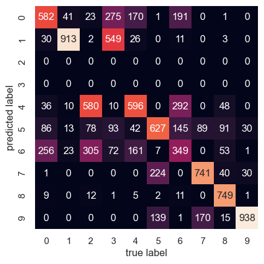

```python
from sklearn.metrics import confusion_matrix
mat = confusion_matrix(fashion['label'], labels)
sns.heatmap(mat.T, square=True, annot=True, fmt='d', cbar=False,
        xticklabels=target_names,
        yticklabels=target_names)
plt.xlabel('true label')
plt.ylabel('predicted label');
```

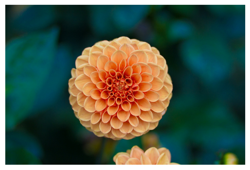

```python
from sklearn.datasets import load_sample_image
flower = load_sample_image("flower.jpg")
ax = plt.axes(xticks=[], yticks=[])
ax.imshow(flower);
```

```python
flower.shape
```

```
(427, 640, 3)
```

```python
data = flower / 255.0 # use 0...1 scale
data = data.reshape(427 * 640, 3)
data.shape
```

```
(273280, 3)
```

```python
def plot_pixels(data, title, colors=None, N=10000):
    if colors is None:
        colors = data
    # choose a random subset
    rng = np.random.RandomState(0)
    i = rng.permutation(data.shape[0])[:N]
    colors = colors[i]
    R, G, B = data[i].T
    fig, ax = plt.subplots(1, 2, figsize=(16, 6))
    ax[0].scatter(R, G, color=colors, marker='.')
    ax[0].set(xlabel='Red', ylabel='Green', xlim=(0, 1), ylim=(0, 1))
    ax[1].scatter(R, B, color=colors, marker='.')
    ax[1].set(xlabel='Red', ylabel='Blue', xlim=(0, 1), ylim=(0, 1))
    fig.suptitle(title, size=20);
```

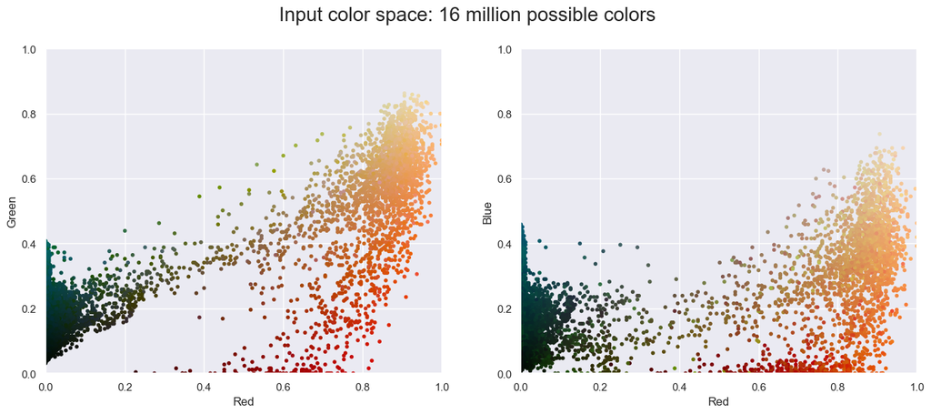

```python
plot_pixels(data, title='Input color space: 16 million possible colors')
```

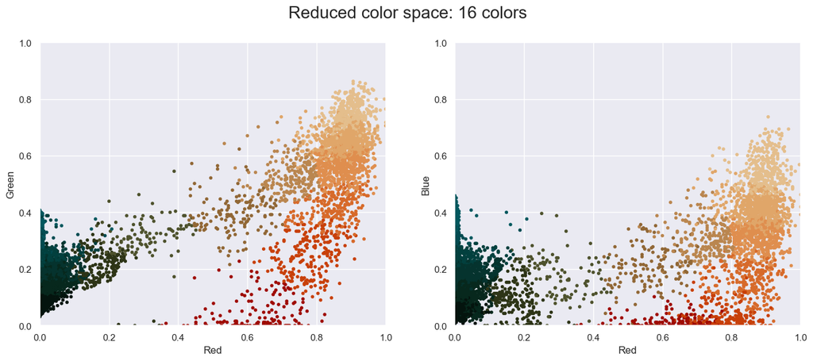

```python
import warnings; warnings.simplefilter('ignore') # Fix NumPy issues.
from sklearn.cluster import MiniBatchKMeans
kmeans = MiniBatchKMeans(16)
kmeans.fit(data)
new_colors = kmeans.cluster_centers_[kmeans.predict(data)]
plot_pixels(data, colors=new_colors,
title="Reduced color space: 16 colors")
```

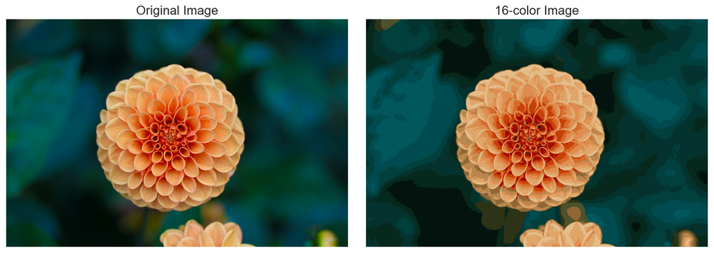

```python
flower_recolored = new_colors.reshape(flower.shape)
fig, ax = plt.subplots(1, 2, figsize=(16, 6),
subplot_kw=dict(xticks=[], yticks=[]))
fig.subplots_adjust(wspace=0.05)
ax[0].imshow(flower)
ax[0].set_title('Original Image', size=16)
ax[1].imshow(flower_recolored)
ax[1].set_title('16-color Image', size=16);
```

```python
import pandas as pd
import numpy as np
import matplotlib.pyplot as plt
from mpl_toolkits.mplot3d import Axes3D
from sklearn import datasets
from sklearn.decomposition import PCA
```

```python
# Dataset
cancer = datasets.load_breast_cancer()
data = pd.DataFrame(cancer.data, columns = cancer.feature_names)
target = cancer.target_names
labels = cancer.target
```

```python
#Scaling
from sklearn.preprocessing import MinMaxScaler
scaler = MinMaxScaler()
data = pd.DataFrame(scaler.fit_transform(data), columns=data.columns)
data
```

|  | mean radius | mean texture | mean perimeter | mean area | mean smoothness | mean compactness | mean concavity | mean concave points | mean symmetry | mean fractal dimension | ... | worst radius | worst texture | worst perimeter | worst area | worst smoothness | worst compactness | worst concavity | worst concave points | worst symmetry | worst fractal dimension |
| --- | --- | --- | --- | --- | --- | --- | --- | --- | --- | --- | --- | --- | --- | --- | --- | --- | --- | --- | --- | --- | --- |
| 0 | 0.521037 | 0.022658 | 0.545989 | 0.363733 | 0.593753 | 0.792037 | 0.703140 | 0.731113 | 0.686364 | 0.605518 | ... | 0.620776 | 0.141525 | 0.668310 | 0.450698 | 0.601136 | 0.619292 | 0.568610 | 0.912027 | 0.598462 | 0.418864 |
| 1 | 0.643144 | 0.272574 | 0.615783 | 0.501591 | 0.289880 | 0.181768 | 0.203608 | 0.348757 | 0.379798 | 0.141323 | ... | 0.606901 | 0.303571 | 0.539818 | 0.435214 | 0.347553 | 0.154563 | 0.192971 | 0.639175 | 0.233590 | 0.222878 |
| 2 | 0.601496 | 0.390260 | 0.595743 | 0.449417 | 0.514309 | 0.431017 | 0.462512 | 0.635686 | 0.509596 | 0.211247 | ... | 0.556386 | 0.360075 | 0.508442 | 0.374508 | 0.483590 | 0.385375 | 0.359744 | 0.835052 | 0.403706 | 0.213433 |
| 3 | 0.210090 | 0.360839 | 0.233501 | 0.102906 | 0.811321 | 0.811361 | 0.565604 | 0.522863 | 0.776263 | 1.000000 | ... | 0.248310 | 0.385928 | 0.241347 | 0.094008 | 0.915472 | 0.814012 | 0.548642 | 0.884880 | 1.000000 | 0.773711 |
| 4 | 0.629893 | 0.156578 | 0.630986 | 0.489290 | 0.430351 | 0.347893 | 0.463918 | 0.518390 | 0.378283 | 0.186816 | ... | 0.519744 | 0.123934 | 0.506948 | 0.341575 | 0.437364 | 0.172415 | 0.319489 | 0.558419 | 0.157500 | 0.142595 |
| ... | ... | ... | ... | ... | ... | ... | ... | ... | ... | ... | ... | ... | ... | ... | ... | ... | ... | ... | ... | ... | ... |
| 564 | 0.690000 | 0.428813 | 0.678668 | 0.566490 | 0.526948 | 0.296055 | 0.571462 | 0.690358 | 0.336364 | 0.132056 | ... | 0.623266 | 0.383262 | 0.576174 | 0.452664 | 0.461137 | 0.178527 | 0.328035 | 0.761512 | 0.097575 | 0.105667 |
| 565 | 0.622320 | 0.626987 | 0.604036 | 0.474019 | 0.407782 | 0.257714 | 0.337395 | 0.486630 | 0.349495 | 0.113100 | ... | 0.560655 | 0.699094 | 0.520892 | 0.379915 | 0.300007 | 0.159997 | 0.256789 | 0.559450 | 0.198502 | 0.074315 |
| 566 | 0.455251 | 0.621238 | 0.445788 | 0.303118 | 0.288165 | 0.254340 | 0.216753 | 0.263519 | 0.267677 | 0.137321 | ... | 0.393099 | 0.589019 | 0.379949 | 0.230731 | 0.282177 | 0.273705 | 0.271805 | 0.487285 | 0.128721 | 0.151909 |
| 567 | 0.644564 | 0.663510 | 0.665538 | 0.475716 | 0.588336 | 0.790197 | 0.823336 | 0.755467 | 0.675253 | 0.425442 | ... | 0.633582 | 0.730277 | 0.668310 | 0.402035 | 0.619626 | 0.815758 | 0.749760 | 0.910653 | 0.497142 | 0.452315 |
| 568 | 0.036869 | 0.501522 | 0.028540 | 0.015907 | 0.000000 | 0.074351 | 0.000000 | 0.000000 | 0.266162 | 0.187026 | ... | 0.054287 | 0.489072 | 0.043578 | 0.020497 | 0.124084 | 0.036043 | 0.000000 | 0.000000 | 0.257441 | 0.100682 |

569 rows × 30 columns

```python
#PCA Transformation
from sklearn.decomposition import PCA
pca = PCA(n_components=3)
principalComponents = pca.fit_transform(data)
PCAdf = pd.DataFrame(data = principalComponents , columns = ['principal component 1', 'principal component 2','principal component 3'])

datapoints = PCAdf.values
m, f = datapoints.shape
k = 3
datapoints
```

```
array([[ 1.38702121,  0.42689537, -0.54170323],
       [ 0.46230825, -0.55694672, -0.20517496],
       [ 0.95462147, -0.10970115, -0.1478485 ],
       ...,
       [ 0.22631131, -0.28794577,  0.31522418],
       [ 1.67783369,  0.33594597,  0.29611584],
       [-0.90506804, -0.10410869,  0.38285893]])
```

```python
#Visualization
fig = plt.figure(1, figsize=(8, 6))
ax = Axes3D(fig, elev=-150, azim=110)
X_reduced = datapoints
ax.scatter(X_reduced[:, 0], X_reduced[:, 1], X_reduced[:, 2], c=labels,
cmap=plt.cm.Set1, edgecolor='k', s=40)
ax.set_title("First three PCA directions")
ax.set_xlabel("principal component 1")
ax.w_xaxis.set_ticklabels([])
ax.set_ylabel("principal component 1")
ax.w_yaxis.set_ticklabels([])
ax.set_zlabel("principal component 1")
ax.w_zaxis.set_ticklabels([])
plt.show()
```

[output not shown]

```python
def init_medoids(X, k):
    from numpy.random import choice
    from numpy.random import seed
    seed(1)
    samples = choice(len(X), size=k, replace=False)
    return X[samples, :]
medoids_initial = init_medoids(datapoints, 2)
medoids_initial
```

```
array([[ 0.22855736,  0.32421808, -0.2320222 ],
       [ 0.33193291,  0.40145146, -0.05743553]])
```

```python
def compute_d_p(X, medoids, p):
    m = len(X)
    medoids_shape = medoids.shape
    # If a 1-D array is provided,
    # it will be reshaped to a single row 2-D array
    if len(medoids_shape) == 1:
        medoids = medoids.reshape((1,len(medoids)))
    k = len(medoids)
    S = np.empty((m, k))
    for i in range(m):
        d_i = np.linalg.norm(X[i, :] - medoids, ord=p, axis=1)
        S[i, :] = d_i**p
    return S
S = compute_d_p(datapoints, medoids_initial, 2)
S
```

```
array([[1.44848346, 1.34837393],
       [0.83181165, 0.95735173],
       [0.7225402 , 0.65719254],
       ...,
       [0.67422822, 0.62529973],
       [2.3794692 , 1.94073845],
       [1.84664918, 1.97962163]])
```

```python
def assign_labels(S):
    return np.argmin(S, axis=1)
labels = assign_labels(S)
labels
```

```
array([1, 0, 1, 1, 0, 1, 0, 1, 1, 1, 0, 1, 1, 0, 1, 1, 0, 1, 1, 0, 0, 0,
       1, 1, 1, 1, 1, 0, 1, 0, 1, 1, 1, 1, 1, 1, 1, 0, 0, 1, 0, 1, 1, 1,
       0, 1, 0, 1, 0, 0, 0, 0, 0, 0, 0, 0, 1, 1, 0, 0, 0, 0, 1, 0, 1, 1,
       0, 0, 1, 0, 0, 0, 1, 0, 0, 0, 0, 1, 1, 0, 0, 0, 1, 1, 0, 0, 1, 1,
       0, 0, 0, 0, 0, 0, 1, 1, 0, 0, 0, 1, 1, 0, 0, 0, 0, 1, 0, 0, 1, 0,
       0, 0, 1, 0, 0, 0, 0, 1, 1, 0, 0, 0, 1, 0, 0, 0, 1, 0, 0, 1, 0, 0,
       1, 0, 0, 0, 0, 0, 0, 0, 0, 0, 0, 0, 0, 0, 1, 0, 0, 0, 0, 1, 1, 0,
       0, 0, 1, 0, 0, 0, 0, 0, 1, 0, 1, 0, 0, 0, 1, 0, 0, 0, 0, 0, 0, 0,
       1, 1, 0, 0, 1, 1, 0, 0, 0, 0, 0, 0, 0, 0, 1, 0, 0, 1, 1, 0, 1, 0,
       1, 1, 0, 0, 1, 1, 0, 0, 0, 0, 1, 0, 1, 0, 0, 1, 1, 1, 0, 0, 1, 1,
       0, 0, 0, 1, 0, 0, 0, 0, 0, 1, 1, 0, 1, 1, 0, 0, 1, 0, 1, 1, 0, 0,
       1, 0, 1, 0, 0, 0, 0, 0, 1, 0, 1, 0, 0, 0, 1, 1, 1, 1, 1, 0, 1, 0,
       0, 1, 0, 0, 0, 0, 0, 0, 1, 0, 0, 0, 0, 0, 0, 0, 1, 0, 1, 1, 0, 0,
       0, 0, 1, 0, 1, 0, 0, 0, 0, 0, 0, 0, 0, 0, 1, 0, 1, 0, 0, 0, 0, 0,
       0, 0, 0, 0, 0, 0, 0, 0, 0, 0, 1, 0, 0, 0, 0, 1, 0, 0, 0, 0, 1, 1,
       0, 0, 0, 0, 0, 1, 0, 1, 0, 1, 0, 0, 0, 1, 0, 0, 0, 0, 0, 0, 0, 1,
       1, 1, 0, 0, 0, 0, 0, 0, 0, 0, 0, 0, 0, 0, 1, 0, 0, 1, 1, 0, 0, 0,
       0, 0, 1, 0, 0, 1, 0, 0, 0, 0, 0, 0, 0, 0, 0, 1, 0, 0, 1, 1, 0, 0,
       0, 0, 0, 0, 1, 0, 0, 0, 0, 0, 0, 0, 0, 0, 0, 0, 0, 1, 1, 0, 0, 1,
       0, 0, 0, 0, 0, 0, 0, 0, 0, 0, 0, 0, 1, 0, 1, 1, 0, 1, 0, 0, 0, 0,
       0, 1, 0, 0, 0, 0, 1, 0, 0, 1, 1, 1, 1, 0, 0, 1, 1, 0, 0, 0, 1, 1,
       0, 0, 0, 1, 0, 0, 1, 1, 0, 0, 0, 1, 0, 0, 0, 0, 0, 1, 0, 0, 0, 0,
       0, 1, 0, 1, 0, 0, 0, 0, 0, 0, 0, 0, 0, 0, 0, 1, 0, 1, 0, 0, 0, 1,
       0, 0, 0, 1, 0, 0, 1, 0, 0, 0, 0, 0, 0, 0, 0, 1, 0, 0, 0, 0, 0, 0,
       0, 0, 0, 0, 0, 1, 0, 1, 1, 1, 0, 1, 0, 1, 0, 0, 0, 0, 0, 0, 0, 0,
       0, 0, 0, 0, 1, 1, 0, 0, 0, 1, 1, 0, 1, 1, 1, 1, 1, 1, 0],
      dtype=int64)
```

```python
def update_medoids(X, medoids, p):
    S = compute_d_p(datapoints, medoids, p)
    labels = assign_labels(S)
    out_medoids = medoids
    for i in set(labels):
        avg_dissimilarity = np.sum(compute_d_p(datapoints, medoids[i], p))
        cluster_points = datapoints[labels == i]
        for datap in cluster_points:
            new_medoid = datap
            new_dissimilarity= np.sum(compute_d_p(datapoints, datap, p))
            if new_dissimilarity < avg_dissimilarity :
                avg_dissimilarity = new_dissimilarity
                out_medoids[i] = datap
    return out_medoids
```

```python
def has_converged(old_medoids, medoids):
    return set([tuple(x) for x in old_medoids]) == set([tuple(x) for x in medoids])
```

```python
#Full algorithm
def kmedoids(X, k, p, starting_medoids=None, max_steps=np.inf):
    if starting_medoids is None:
        medoids = init_medoids(X, k)
    else:
        medoids = starting_medoids
    converged = False
    labels = np.zeros(len(X))
    i = 1
    while (not converged) and (i <= max_steps):
        old_medoids = medoids.copy()
        S = compute_d_p(X, medoids, p)
        labels = assign_labels(S)
        medoids = update_medoids(X, medoids, p)
        converged = has_converged(old_medoids, medoids)
        i += 1
    return (medoids,labels)
results = kmedoids(datapoints, 2, 2)
final_medoids = results[0]
data['clusters'] = results[1]
results
```

```
(array([[-0.00085863,  0.03108443, -0.01858692],
        [-0.03839918,  0.03835598,  0.03360457]]),
 array([0, 0, 0, 0, 0, 0, 0, 0, 0, 0, 1, 0, 0, 1, 0, 0, 0, 0, 0, 0, 0, 1,
        0, 0, 0, 0, 0, 0, 0, 0, 0, 0, 0, 0, 0, 0, 0, 1, 1, 0, 1, 1, 0, 0,
        1, 0, 1, 0, 1, 1, 1, 1, 1, 0, 1, 1, 0, 0, 1, 1, 1, 1, 0, 1, 0, 0,
        1, 1, 0, 1, 0, 1, 0, 0, 1, 0, 0, 0, 0, 1, 1, 0, 0, 0, 1, 0, 1, 0,
        1, 0, 1, 0, 1, 1, 0, 0, 1, 1, 0, 1, 1, 1, 1, 1, 1, 0, 1, 1, 0, 1,
        1, 1, 0, 1, 1, 1, 1, 0, 0, 0, 0, 0, 0, 0, 1, 1, 1, 0, 0, 0, 0, 0,
        0, 0, 0, 1, 1, 1, 0, 0, 1, 0, 1, 1, 1, 0, 0, 1, 0, 1, 1, 1, 0, 1,
        0, 1, 0, 1, 1, 1, 1, 0, 0, 1, 0, 1, 1, 0, 0, 1, 0, 1, 0, 1, 1, 1,
        1, 0, 1, 1, 0, 0, 0, 1, 0, 1, 0, 1, 1, 1, 0, 1, 1, 1, 0, 1, 1, 0,
        0, 0, 1, 0, 0, 0, 1, 0, 1, 0, 1, 0, 0, 1, 0, 0, 1, 0, 1, 1, 0, 0,
        0, 0, 1, 0, 1, 0, 1, 0, 1, 0, 0, 1, 1, 0, 1, 1, 0, 0, 1, 1, 0, 1,
        1, 1, 0, 1, 1, 0, 1, 1, 0, 1, 0, 0, 0, 0, 0, 0, 0, 1, 0, 1, 0, 1,
        0, 0, 1, 1, 1, 1, 1, 1, 0, 1, 1, 1, 1, 0, 1, 0, 0, 1, 0, 0, 1, 1,
        1, 1, 1, 1, 0, 0, 0, 1, 1, 1, 1, 1, 1, 1, 0, 1, 0, 1, 1, 1, 1, 1,
        1, 1, 1, 1, 0, 1, 1, 1, 1, 0, 1, 1, 1, 0, 0, 0, 1, 1, 1, 1, 0, 0,
        0, 1, 1, 1, 1, 0, 1, 0, 1, 0, 0, 1, 1, 0, 1, 1, 1, 0, 1, 1, 1, 0,
        0, 1, 1, 1, 0, 1, 1, 1, 1, 1, 1, 0, 1, 0, 0, 1, 0, 0, 0, 0, 0, 0,
        1, 0, 0, 1, 0, 0, 0, 1, 1, 1, 0, 1, 1, 1, 1, 0, 1, 1, 0, 0, 1, 1,
        0, 1, 1, 1, 0, 1, 1, 1, 1, 1, 0, 1, 0, 1, 1, 1, 1, 1, 1, 1, 1, 0,
        0, 1, 1, 0, 0, 0, 1, 1, 1, 1, 1, 1, 0, 1, 0, 0, 0, 0, 1, 1, 1, 1,
        1, 0, 1, 1, 0, 1, 0, 0, 1, 0, 1, 0, 1, 0, 1, 1, 1, 1, 1, 1, 0, 0,
        1, 1, 1, 0, 1, 1, 0, 1, 1, 1, 0, 1, 1, 0, 1, 1, 1, 0, 1, 1, 0, 1,
        0, 0, 1, 0, 1, 0, 1, 0, 0, 1, 1, 1, 0, 1, 0, 0, 0, 0, 1, 0, 0, 0,
        1, 1, 0, 0, 1, 0, 0, 0, 1, 1, 0, 0, 0, 1, 1, 0, 1, 1, 1, 1, 0, 0,
        0, 0, 1, 1, 1, 0, 1, 0, 1, 1, 1, 1, 1, 1, 1, 1, 1, 1, 1, 1, 1, 1,
        1, 1, 1, 1, 1, 1, 1, 1, 1, 1, 1, 1, 0, 0, 0, 0, 1, 0, 1],
       dtype=int64))
```

```python
#Count
def mark_matches(a, b, exact=False):
    assert a.shape == b.shape
    a_int = a.astype(dtype=int)
    b_int = b.astype(dtype=int)
    all_axes = tuple(range(len(a.shape)))
    assert ((a_int == 0) | (a_int == 1) | (a_int == 2)).all()
    assert ((b_int == 0) | (b_int == 1) | (b_int == 2)).all()
    exact_matches = (a_int == b_int)
    if exact:
        return exact_matches
    assert exact == False
    num_exact_matches = np.sum(exact_matches)
    if (2*num_exact_matches) >= np.prod (a.shape):
        return exact_matches
    return exact_matches == False # Invert
```

```python
def count_matches(a, b, exact=False):
    matches = mark_matches(a, b, exact=exact)
    return np.sum(matches)
n_matches = count_matches(labels, data['clusters'])
print(n_matches,
        "matches out of",
        len(data), "data points",
        "(~ {:.1f}%)".format(100.0 * n_matches / len(labels)))
```

```
420 matches out of 569 data points (~ 73.8%)
```

```python
import warnings
warnings.filterwarnings('ignore')
import numpy as np
import pandas as pd
import matplotlib.pyplot as plt
import seaborn as sns
%matplotlib inline
from matplotlib.pyplot import xticks
```

```python
gender = pd.read_csv('gender_classification.csv')
```

```python
gender.head()
```

|  | Favorite Color | Favorite Music Genre | Favorite Beverage | Favorite Soft Drink | Gender |
| --- | --- | --- | --- | --- | --- |
| 0 | Cool | Rock | Vodka | 7UP/Sprite | F |
| 1 | Neutral | Hip hop | Vodka | Coca Cola/Pepsi | F |
| 2 | Warm | Rock | Wine | Coca Cola/Pepsi | F |
| 3 | Warm | Folk/Traditional | Whiskey | Fanta | F |
| 4 | Cool | Rock | Vodka | Coca Cola/Pepsi | F |

```python
gender.columns
```

```
Index(['Favorite Color', 'Favorite Music Genre', 'Favorite Beverage',
       'Favorite Soft Drink', 'Gender'],
      dtype='object')
```

```python
from sklearn import preprocessing
le = preprocessing.LabelEncoder()
gender = gender.apply(le.fit_transform)
gender.head()
```

|  | Favorite Color | Favorite Music Genre | Favorite Beverage | Favorite Soft Drink | Gender |
| --- | --- | --- | --- | --- | --- |
| 0 | 0 | 6 | 3 | 0 | 0 |
| 1 | 1 | 2 | 3 | 1 | 0 |
| 2 | 2 | 6 | 5 | 1 | 0 |
| 3 | 2 | 1 | 4 | 2 | 0 |
| 4 | 0 | 6 | 3 | 1 | 0 |

```python
gender_class = gender[['Favorite Color', 'Favorite Music Genre', 'Favorite Beverage', 'Favorite Soft Drink']]
```

```python
gender_class.head()
```

|  | Favorite Color | Favorite Music Genre | Favorite Beverage | Favorite Soft Drink |
| --- | --- | --- | --- | --- |
| 0 | 0 | 6 | 3 | 0 |
| 1 | 1 | 2 | 3 | 1 |
| 2 | 2 | 6 | 5 | 1 |
| 3 | 2 | 1 | 4 | 2 |
| 4 | 0 | 6 | 3 | 1 |

```python
gender_class.shape
```

```
(66, 4)
```

```python
gender_class.describe()
```

|  | Favorite Color | Favorite Music Genre | Favorite Beverage | Favorite Soft Drink |
| --- | --- | --- | --- | --- |
| count | 66.000000 | 66.000000 | 66.000000 | 66.000000 |
| mean | 0.772727 | 3.696970 | 2.257576 | 1.227273 |
| std | 0.924794 | 2.060394 | 1.739236 | 0.890902 |
| min | 0.000000 | 0.000000 | 0.000000 | 0.000000 |
| 25% | 0.000000 | 2.000000 | 1.000000 | 1.000000 |
| 50% | 0.000000 | 4.000000 | 2.000000 | 1.000000 |
| 75% | 2.000000 | 6.000000 | 4.000000 | 2.000000 |
| max | 2.000000 | 6.000000 | 5.000000 | 3.000000 |

```python
gender_class.info()
```

```
<class 'pandas.core.frame.DataFrame'>
RangeIndex: 66 entries, 0 to 65
Data columns (total 4 columns):
 #   Column                Non-Null Count  Dtype
---  ------                --------------  -----
 0   Favorite Color        66 non-null     int32
 1   Favorite Music Genre  66 non-null     int32
 2   Favorite Beverage     66 non-null     int32
 3   Favorite Soft Drink   66 non-null     int32
dtypes: int32(4)
memory usage: 1.2 KB
```

```python
# Checking Null Values
gender_class.isnull().sum()*100/gender_class.shape[0]
```

```
Favorite Color          0.0
Favorite Music Genre    0.0
Favorite Beverage       0.0
Favorite Soft Drink     0.0
dtype: float64
```

```python
gender_class_copy = gender_class.copy()
```

```python
from sklearn import preprocessing
le = preprocessing.LabelEncoder()
gender_class = gender_class.apply(le.fit_transform)
gender_class.head()
```

|  | Favorite Color | Favorite Music Genre | Favorite Beverage | Favorite Soft Drink |
| --- | --- | --- | --- | --- |
| 0 | 0 | 6 | 3 | 0 |
| 1 | 1 | 2 | 3 | 1 |
| 2 | 2 | 6 | 5 | 1 |
| 3 | 2 | 1 | 4 | 2 |
| 4 | 0 | 6 | 3 | 1 |

```python
!pip install kmodes
```

```python
pip install --upgrade kmode
```

```
ERROR: Could not find a version that satisfies the requirement kmode (from versions: none)
ERROR: No matching distribution found for kmode
```

```python
# Importing Libraries
from kmodes.kmodes import KModes
```

```python
km_cao = KModes(n_clusters=2, init = "Cao", n_init = 1, verbose=1)
fitClusters_cao = km_cao.fit_predict(gender_class)
```

```
Init: initializing centroids
Init: initializing clusters
Starting iterations...
Run 1, iteration: 1/100, moves: 0, cost: 135.0
```

```python
# Predicted Clusters
fitClusters_cao
```

```
array([0, 0, 0, 1, 0, 0, 0, 1, 1, 0, 1, 1, 1, 0, 0, 0, 1, 0, 0, 0, 0, 1,
       0, 1, 0, 0, 0, 0, 0, 0, 0, 0, 0, 1, 1, 1, 0, 1, 0, 1, 0, 1, 0, 0,
       0, 0, 0, 0, 0, 0, 0, 0, 0, 0, 0, 0, 1, 1, 0, 0, 0, 0, 0, 0, 0, 0],
      dtype=uint16)
```

```python
clusterCentroidsDf = pd.DataFrame(km_cao.cluster_centroids_)
clusterCentroidsDf.columns = gender_class.columns
```

```python
# Mode of the clusters
clusterCentroidsDf
```

|  | Favorite Color | Favorite Music Genre | Favorite Beverage | Favorite Soft Drink |
| --- | --- | --- | --- | --- |
| 0 | 0 | 6 | 1 | 1 |
| 1 | 2 | 4 | 2 | 0 |

```python
km_huang = KModes(n_clusters=2, init = "Huang", n_init = 1, verbose=1)
fitClusters_huang = km_huang.fit_predict(gender_class)
```

```
Init: initializing centroids
Init: initializing clusters
Starting iterations...
Run 1, iteration: 1/100, moves: 2, cost: 133.0
```

```python
# Predicted clusters
fitClusters_huang
```

```
array([0, 0, 0, 1, 0, 1, 0, 1, 1, 1, 1, 1, 1, 1, 0, 1, 0, 0, 0, 0, 0, 1,
       0, 1, 0, 1, 0, 0, 0, 0, 1, 0, 0, 1, 0, 1, 0, 1, 0, 0, 0, 1, 1, 0,
       0, 0, 0, 0, 0, 0, 0, 0, 0, 0, 0, 0, 1, 1, 1, 0, 0, 0, 0, 0, 0, 0],
      dtype=uint16)
```

```python
cost = []
for num_clusters in list(range(1,5)):
    kmode = KModes(n_clusters=num_clusters, init = "Cao", n_init = 1, verbose=1)
    kmode.fit_predict(gender_class)
    cost.append(kmode.cost_)
```

```
Init: initializing centroids
Init: initializing clusters
Starting iterations...
Run 1, iteration: 1/100, moves: 0, cost: 162.0
Init: initializing centroids
Init: initializing clusters
Starting iterations...
Run 1, iteration: 1/100, moves: 0, cost: 135.0
Init: initializing centroids
Init: initializing clusters
Starting iterations...
Run 1, iteration: 1/100, moves: 0, cost: 122.0
Init: initializing centroids
Init: initializing clusters
Starting iterations...
Run 1, iteration: 1/100, moves: 0, cost: 111.0
```

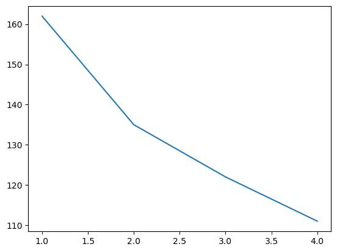

```python
y = np.array([i for i in range(1,5,1)])
plt.plot(y,cost)
```

```python
## Choosing K=2
km_cao = KModes(n_clusters=2, init = "Cao", n_init = 1, verbose=1)
fitClusters_cao = km_cao.fit_predict(gender_class)
```

```
Init: initializing centroids
Init: initializing clusters
Starting iterations...
Run 1, iteration: 1/100, moves: 0, cost: 135.0
```

```python
fitClusters_cao
```

```
array([0, 0, 0, 1, 0, 0, 0, 1, 1, 0, 1, 1, 1, 0, 0, 0, 1, 0, 0, 0, 0, 1,
       0, 1, 0, 0, 0, 0, 0, 0, 0, 0, 0, 1, 1, 1, 0, 1, 0, 1, 0, 1, 0, 0,
       0, 0, 0, 0, 0, 0, 0, 0, 0, 0, 0, 0, 1, 1, 0, 0, 0, 0, 0, 0, 0, 0],
      dtype=uint16)
```

```python
gender_class = gender_class_copy.reset_index()
```

```python
clustersDf = pd.DataFrame(fitClusters_cao)
clustersDf.columns = ['cluster_predicted']
combinedDf = pd.concat([gender_class, clustersDf], axis = 1).reset_index()
combinedDf = combinedDf.drop(['index', 'level_0'], axis = 1)
```

```python
combinedDf.head()
```

|  | Favorite Color | Favorite Music Genre | Favorite Beverage | Favorite Soft Drink | cluster_predicted |
| --- | --- | --- | --- | --- | --- |
| 0 | 0 | 6 | 3 | 0 | 0 |
| 1 | 1 | 2 | 3 | 1 | 0 |
| 2 | 2 | 6 | 5 | 1 | 0 |
| 3 | 2 | 1 | 4 | 2 | 1 |
| 4 | 0 | 6 | 3 | 1 | 0 |

```python
cluster_0 = combinedDf[combinedDf['cluster_predicted'] == 0]
cluster_1 = combinedDf[combinedDf['cluster_predicted'] == 1]
```

```python
cluster_0.info()
```

```
<class 'pandas.core.frame.DataFrame'>
Index: 49 entries, 0 to 65
Data columns (total 5 columns):
 #   Column                Non-Null Count  Dtype
---  ------                --------------  -----
 0   Favorite Color        49 non-null     int32
 1   Favorite Music Genre  49 non-null     int32
 2   Favorite Beverage     49 non-null     int32
 3   Favorite Soft Drink   49 non-null     int32
 4   cluster_predicted     49 non-null     uint16
dtypes: int32(4), uint16(1)
memory usage: 1.2 KB
```

```python
cluster_1.info()
```

```
<class 'pandas.core.frame.DataFrame'>
Index: 17 entries, 3 to 57
Data columns (total 5 columns):
 #   Column                Non-Null Count  Dtype
---  ------                --------------  -----
 0   Favorite Color        17 non-null     int32
 1   Favorite Music Genre  17 non-null     int32
 2   Favorite Beverage     17 non-null     int32
 3   Favorite Soft Drink   17 non-null     int32
 4   cluster_predicted     17 non-null     uint16
dtypes: int32(4), uint16(1)
memory usage: 442.0 bytes
```

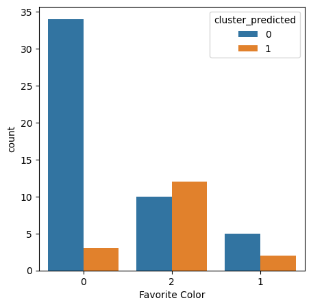

```python
# Favorite Color
plt.subplots(figsize = (5,5))
sns.countplot(x=combinedDf['Favorite Color'],order=combinedDf['Favorite Color'].value_counts().index,hue=combinedDf['cluster_predicted'])
plt.show()
```

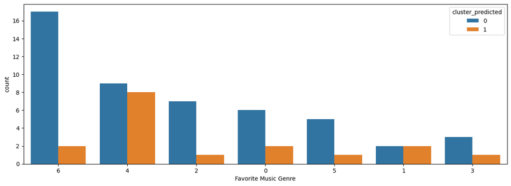

```python
# Favorite Music Genre
plt.subplots(figsize = (15,5))
sns.countplot(x=combinedDf['Favorite Music Genre'],order=combinedDf['Favorite Music Genre'].value_counts().index,hue=combinedDf['cluster_predicted'])
plt.show()
```

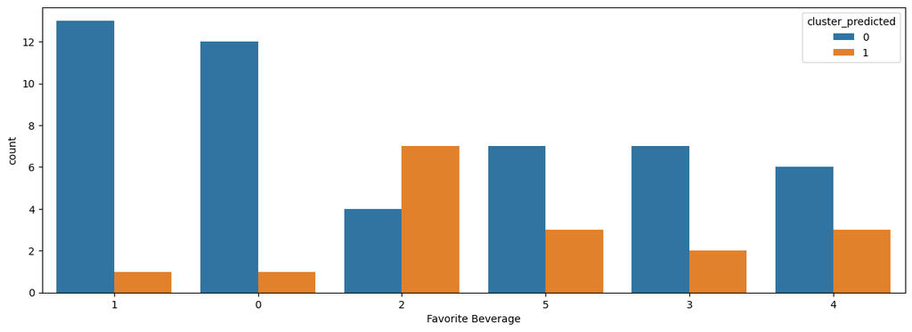

```python
# Favorite Beverage
plt.subplots(figsize = (15,5))
sns.countplot(x=combinedDf['Favorite Beverage'],order=combinedDf['Favorite Beverage'].value_counts().index,hue=combinedDf['cluster_predicted'])
plt.show()
```

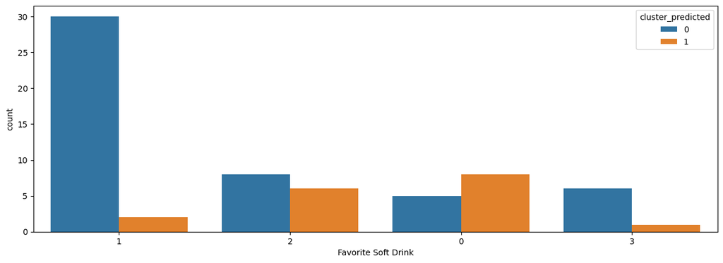

```python
# Favorite Soft Drink
plt.subplots(figsize = (15,5))
sns.countplot(x=combinedDf['Favorite Soft Drink'],order=combinedDf['Favorite Soft Drink'].value_counts().index,hue=combinedDf['cluster_predicted'])
plt.show()
```

```python
#Count
def mark_matches(a, b, exact=False):
    assert a.shape == b.shape
    a_int = a.astype(dtype=int)
    b_int = b.astype(dtype=int)
    all_axes = tuple(range(len(a.shape)))
    assert ((a_int == 0) | (a_int == 1) | (a_int == 2)).all()
    assert ((b_int == 0) | (b_int == 1) | (b_int == 2)).all()
    exact_matches = (a_int == b_int)
    if exact:
        return exact_matches
    assert exact == False
    num_exact_matches = np.sum(exact_matches)
    if (2*num_exact_matches) >= np.prod (a.shape):
        return exact_matches
    return exact_matches == False # Invert
def count_matches(a, b, exact=False):
    matches = mark_matches(a, b, exact=exact)
    return np.sum(matches)
n_matches_kmodes = count_matches(gender['Gender'], combinedDf['cluster_predicted'])
print(n_matches_kmodes,
    "matches out of",
    len(combinedDf), "data points",
    "(~ {:.1f}%)".format(100.0 * n_matches_kmodes / len(gender['Gender'])))
```

```
34 matches out of 66 data points (~ 51.5%)
```

### Kesimpulan

- Algoritma K-Means telah diterapkan pada dataset ini dan berhasil mencapai tingkat akurasi sebesar 55%.
- K-Means juga bisa digunakan untuk melakukan kompresi warna, yang telah diaplikasikan pada gambar flower.jpg yang diambil dari load_sample_image dari sklearn.datasets.

```python
# Footer
myDate = datetime.datetime.now()
print("I certify that this is my own work.")
print("Signed by:")
print("Name: \t\t{}".format(myName))
print("NIM: \t\t{}".format(myNIM))
print("Time-stamp:\t{}".format(myDate))
```

```
I certify that this is my own work.
Signed by:
Name: 		Nisa'ul Fadhilah
NIM: 		0000060236
Time-stamp:	2023-11-02 15:49:46.466813
```

### Save the notebook, then convert the notebook to html (by running the next code).

```python
!jupyter nbconvert --to html "./Challenge_3_dataset an_M9_00000060236_Nisaul Fadhilah.ipynb" --output-dir="./"
```